# Small analysis for Tiwari V. et al.

scRNASeq analysis

Eric Bautista Farrerons

First created on November 2024. Updated on 29 noviembre 2024

# 1 Load and understand data

```r
# Load packages and paths
library(here)
source(here::here("scripts", "functions.R"))
source(here::here("scripts", "paths.R"))
source(here::here("scripts", "install.R"))

# Read data
tpm.rsem <- read.table(here::here("data", "GSE118389_tpm_rsem.txt"), sep = "\t")
counts.rsem <- read.table(here::here("data", "GSE118389_counts_rsem.txt"), sep = "\t")
norm.data <- read.table(here::here("data", "GSE118389_norm_data.txt"), sep = "\t")

# Create path for results
scrnaseq_results_path <- file.path(results_path,
                          "./scrnaseq")
if (!dir.exists(scrnaseq_results_path)) {
  dir.create(scrnaseq_results_path, recursive = TRUE)
}
```

By reading the paper ([Ellisen LW et al.](https://pmc.ncbi.nlm.nih.gov/articles/PMC6123496/) ) I found that the data was already pre-processed and quality checked in `GSE118389_norm_data.txt`. There are 1189 cells left from an initial amount of 1534. So this is the data that I am going to use for the analysis.

# 2 Filtering

Here I want to filter genes that are expressed in a few cells and those that have a low variance.

```r
variance <- rowVars(as.matrix(norm.data))
norm.data2 <- norm.data[variance > quantile(variance, 0.25), ]
```

# 3 Cell type classification

Here I classify the cells by type using the marker genes from the paper (`markers_clean.txt`), although the method is different.

```r
# Load marker genes
all_markers <- read.table(here::here("data", "markers_clean.txt"), sep = "\t", header = TRUE, stringsAsFactors = FALSE)

# Add hgnc_symbol column and filter markers
norm.data2$hgnc_symbol <- rownames(norm.data2)
norm.data2 <- norm.data2[, c("hgnc_symbol", setdiff(names(norm.data2), "hgnc_symbol"))]
markers <- unique(all_markers[all_markers$gene %in% norm.data2$hgnc_symbol, ])
markers <- markers[, !names(markers) %in% "note"] # rm empty column
norm.data2 <- norm.data2[, !colnames(norm.data2) %in% "hgnc_symbol"] # rm hgnc_symbol column

# Adjust labels for plotting
markers$type_short <- markers$type
markers$type_short[which(markers$type == "luminalprogenitor")] <- "luminal progenitor"
markers$type_short[which(markers$type == "luminalepithelial")] <- "luminal epithelial"
markers$type_short[which(markers$type == "basalepithelial")] <- "basal epithelial"
markers$type_short[which(markers$type %in% c("EPCAM", "EGFR", "CDH1"))] <- "epithelial"
markers$type_short[which(markers$type == "Bcell")] <- "B cell"
markers$type_short[which(markers$type == "Tcell")] <- "T cell"
markers$type_short[which(markers$type == "stroma")] <- "stroma"
markers$type_short[which(markers$type == "endothelial")] <- "endothelial"

# Classify
thresh <- 1 # Same threshold as paper
cells_markers <- lists_markers(norm.data2, thresh, markers)

## Epithelial
epithelial_markers <- cells_markers$epithelial_cells
is_epithelial <- decide_is_epithelial(epithelial_markers)

## Immune
immune_markers <- cells_markers$immune_cells
is_immune <- decide_is_immune(immune_markers)

## Other
other_markers <- cells_markers$other_cells
is_other <- decide_is_other(other_markers)

## Epithelial with only 1 marker gene
# Using  empirical cumulative distribution function within same patient
one_epithelial_marker <- expression_one_epithelial_marker(norm.data2, is_epithelial, epithelial_markers, "pats", 0.5)
is_epithelial[which(one_epithelial_marker$is_epithelial_extra == 1)] <- 1

## Simplify type labels
is_epithelial_simple <- is_epithelial
is_epithelial_simple[which(is_epithelial == 1)] <- "epithelial"
is_immune_simple <- is_immune
is_immune_simple[which(is_immune == "immune_mix")] <- 0
is_other_simple <- is_other
is_other_simple[which(is_other == "other_mix")] <- 0

## Group cell types
cells_types <- paste(is_epithelial_simple, is_immune_simple, is_other_simple, sep = "_")
names(cells_types) <- names(is_epithelial)
cell_types <- sapply(strsplit(cells_types, "_"), function(x){
  # if none of the cell types (epithelial, immune, other), return unknown
  if (sum(x == 0) == 3) return("unknown") else
    # if only one cell type was assigned, return that
    if (sum(x == 0) == 2) return(setdiff(x, "0")) else
      # if endothelial and stroma, return endothelial
      if (sum(c("epithelial", "stroma", "0") %in% x) == 3) return("epithelial") else
        # Ambiguous cases
        return(paste(setdiff(x, "0"),collapse = "_"))})
cell_types_simple <- cell_types
cell_types_simple[which(sapply(strsplit(cell_types, "_"), length) > 1)] <- "unknown"
table(cell_types_simple)
```

```
## cell_types_simple
##       Bcell endothelial  epithelial  macrophage      stroma       Tcell
##          19          14         831          51          95          53
##     unknown
##         126
```

```r
## Further refinement is done in the original paper, but I decided to stop here
```

# 4 Bar plot of cell types

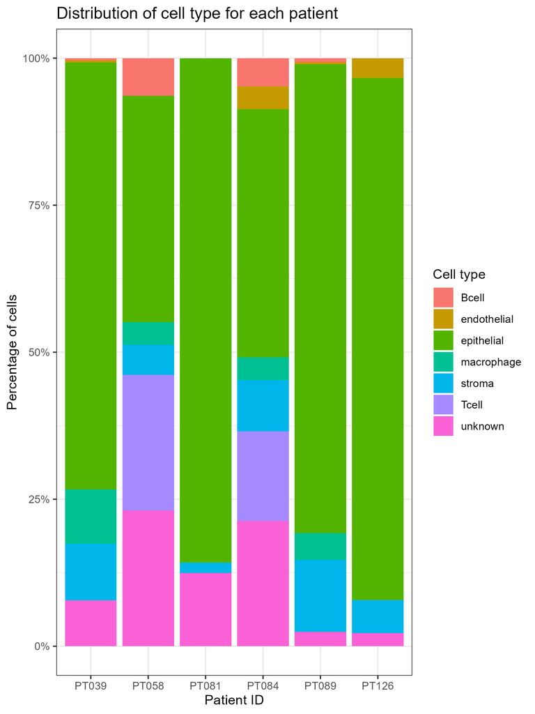

```r
# Extract Patient IDs
patient_ids <- sub("_.*$", "", names(cell_types_simple))

# Create a data frame
data <- data.frame(
  patient_id = patient_ids,
  cell_type = cell_types_simple
)

# Calculate proportions for each cell type within each patient
data_summary <- data %>%
  group_by(patient_id, cell_type) %>%
  dplyr::summarise(Count = n(), .groups = "drop") %>%
  group_by(patient_id) %>%
  dplyr::mutate(Proportion = Count / sum(Count))

# Create a stacked bar plot
plot <- ggplot(data_summary, aes(x = patient_id, y = Proportion, fill = cell_type)) +
  geom_bar(stat = "identity", position = "stack") +
  scale_y_continuous(labels = scales::percent_format()) +
  labs(
    title = "Distribution of cell type for each patient",
    x = "Patient ID",
    y = "Percentage of cells",
    fill = "Cell type"
  ) +
  theme_bw()

# Save the plot
ggsave(
    filename = file.path(scrnaseq_results_path, "barplot_cell_types_patients.png"),
    plot = plot,
    width = 6,
    height = 8
  )

# Display the PNG image
knitr::include_graphics(file.path(scrnaseq_results_path, "barplot_cell_types_patients.png"))
```

The results are a bit different from the paper because I didn’t do the refinement of cell type classification, so I have more cells classified as epithelial and less in other types. However, the results are similar.

# 5 Dimensionality reduction

Here I want to do dimensionality reduction by using t-SNE. I chose t-SNE over UMAP because the dataset is rather small and I am interested in seeing discrete cell populations clearly separated in clusters. I used a perplexity of 30.

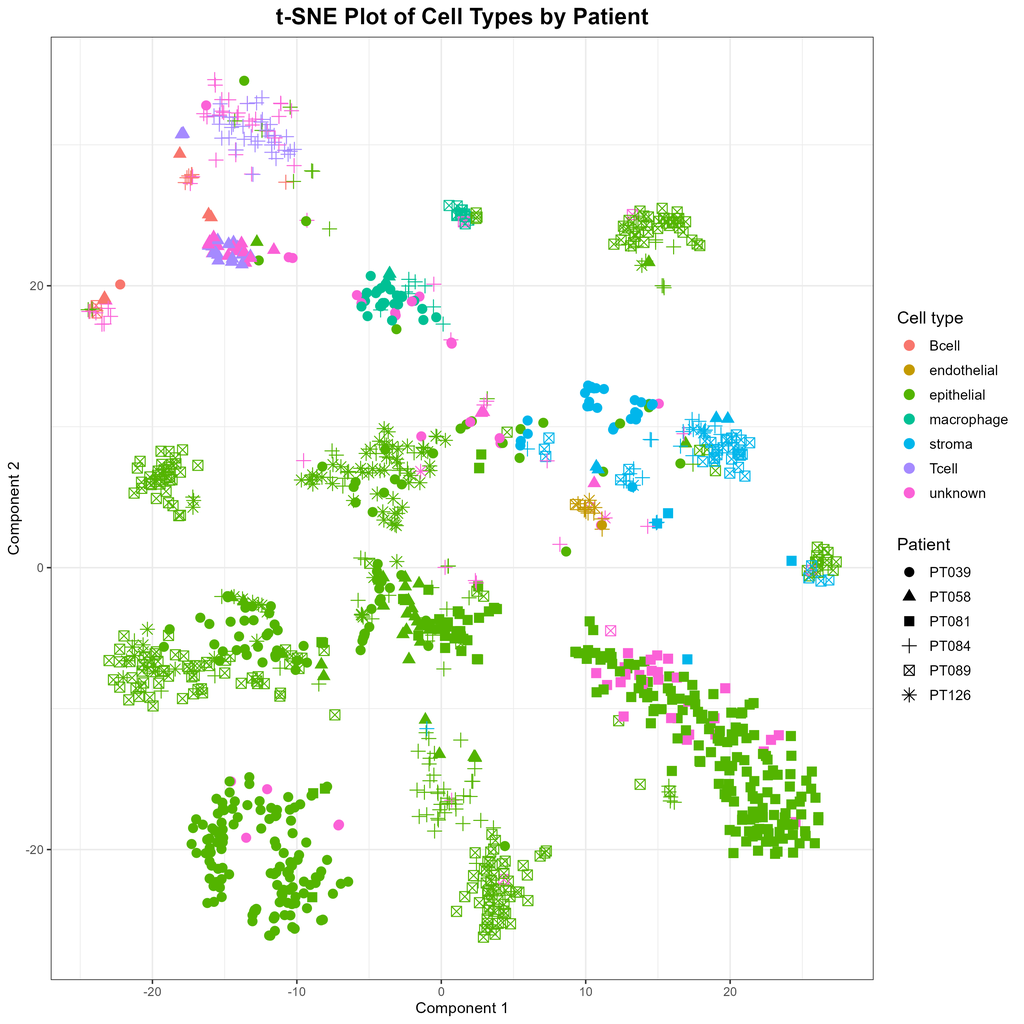

```r
# Add small noise because 2 genes have the same values
norm.data2_noisy <- norm.data2 + matrix(rnorm(length(norm.data2), mean = 0, sd = 1e-6), nrow = nrow(norm.data2))

# Run t-SNE
tsne_results <- Rtsne(t(norm.data2_noisy), perplexity = 30)
tsne_df <- as.data.frame(tsne_results$Y)
colnames(tsne_df) <- c("tSNE1", "tSNE2")
tsne_df$cell_type <- data$cell_type
tsne_df$patient_id <- data$patient_id

# Plot
plot2 <- ggplot(tsne_df, aes(x = tSNE1, y = tSNE2, color = cell_type, shape = patient_id)) +
  geom_point(size = 3) +
  labs(
    title = "t-SNE Plot of Cell Types by Patient",
    x = "Component 1",
    y = "Component 2",
    color = "Cell type",
    shape = "Patient"
  ) +
  theme_bw() +
  theme(
    plot.title = element_text(hjust = 0.5, face = "bold", size = 16),
    legend.title = element_text(size = 12),
    legend.text = element_text(size = 10)
  )

# Save the plot
ggsave(
    filename = file.path(scrnaseq_results_path, "tsne_cell_types_patients.png"),
    plot = plot2,
    width = 10,
    height = 10
  )

# Display the PNG image
knitr::include_graphics(file.path(scrnaseq_results_path, "tsne_cell_types_patients.png"))
```

Results are similar to the paper, where we can see that the different non-epithelial cell types form defined clusters, and the epithelial cells formed different subgroups.